# storm_analysis

van Dam

7/16/2017

# Reproducible Research : Project-2

Analysis to determine which natural hazard causes the most damage to people, property, and crops as presented in the NOAA storm database.

Load the data into R

```r
setwd("/Users/tonie.vandam/Downloads/data_science/storm")
storm <- read.csv("repdata-data-StormData.csv")
head(storm)
```

```
##   STATE__           BGN_DATE BGN_TIME TIME_ZONE COUNTY COUNTYNAME STATE
## 1       1  4/18/1950 0:00:00     0130       CST     97     MOBILE    AL
## 2       1  4/18/1950 0:00:00     0145       CST      3    BALDWIN    AL
## 3       1  2/20/1951 0:00:00     1600       CST     57    FAYETTE    AL
## 4       1   6/8/1951 0:00:00     0900       CST     89    MADISON    AL
## 5       1 11/15/1951 0:00:00     1500       CST     43    CULLMAN    AL
## 6       1 11/15/1951 0:00:00     2000       CST     77 LAUDERDALE    AL
##    EVTYPE BGN_RANGE BGN_AZI BGN_LOCATI END_DATE END_TIME COUNTY_END
## 1 TORNADO         0                                               0
## 2 TORNADO         0                                               0
## 3 TORNADO         0                                               0
## 4 TORNADO         0                                               0
## 5 TORNADO         0                                               0
## 6 TORNADO         0                                               0
##   COUNTYENDN END_RANGE END_AZI END_LOCATI LENGTH WIDTH F MAG FATALITIES
```

[output cut: 20 more lines]

## Introduction

This analysis focuses only on the health and economic consequences of severe weather events => only a subset of the data are required. According to the document storm_data_info.pdf we need: EVTYPE, FATALITIES, INJURIES, PROPDMG, PROPDMGEXP CROPDMG CROPDMGEXP. These are the event type, fatalities, injurites, property damage, property damage exponent, crop damage, and crop damage exponent.

## Data Analysis

```r
stormSS <- storm[,c("EVTYPE", "FATALITIES", "INJURIES", "PROPDMG","CROPDMG")]
```

the exponents mean that we multiply the property damage and crop damage by 10 to the exponent. EXP can equal h/H, k/K, m/M, b/B that indicate hundreds, thousands, millions, and billions of dollars

Look at the damage and figure out how to assign the exponents to the property and crop damage

```r
unique(storm$PROPDMGEXP)
```

```
##  [1] K M   B m + 0 5 6 ? 4 2 3 h 7 H - 1 8
## Levels:  - ? + 0 1 2 3 4 5 6 7 8 B h H K m M
```

Now convert those symbols/numbers into consistent multipliers First let’s process the property exponential and create a new numeric variable

```r
stormSS$PDMGMULTIPLY[storm$PROPDMGEXP == "B"] <- 1e+09
stormSS$PDMGMULTIPLY[storm$PROPDMGEXP == "M"] <- 1e+06
stormSS$PDMGMULTIPLY[storm$PROPDMGEXP == "m"] <- 1e+06
stormSS$PDMGMULTIPLY[storm$PROPDMGEXP == "K"] <- 1e+03
stormSS$PDMGMULTIPLY[storm$PROPDMGEXP == "h"] <- 1e+02
stormSS$PDMGMULTIPLY[storm$PROPDMGEXP == "H"] <- 1e+02
stormSS$PDMGMULTIPLY[storm$PROPDMGEXP == ""] <- 1
stormSS$PDMGMULTIPLY[storm$PROPDMGEXP == "0"] <- 1
stormSS$PDMGMULTIPLY[storm$PROPDMGEXP == "5"] <- 1e+05
stormSS$PDMGMULTIPLY[storm$PROPDMGEXP == "6"] <- 1e+06
stormSS$PDMGMULTIPLY[storm$PROPDMGEXP == "4"] <- 1e+04
stormSS$PDMGMULTIPLY[storm$PROPDMGEXP == "2"] <- 1e+02
stormSS$PDMGMULTIPLY[storm$PROPDMGEXP == "3"] <- 1e+03
stormSS$PDMGMULTIPLY[storm$PROPDMGEXP == "7"] <- 1e+07
stormSS$PDMGMULTIPLY[storm$PROPDMGEXP == "1"] <- 10
stormSS$PDMGMULTIPLY[storm$PROPDMGEXP == "8"] <- 1e+08
#invalid exponents assign a value of '0'
stormSS$PDMGMULTIPLY[storm$PROPDMGEXP == "+"] <- 0
stormSS$PDMGMULTIPLY[storm$PROPDMGEXP == "-"] <- 0
stormSS$PDMGMULTIPLY[storm$PROPDMGEXP == "?"] <- 0
# calculate the property damage value
stormSS$PROPDMGVAL <- storm$PROPDMG * stormSS$PDMGMULTIPLY
```

Now process the crop exponential and create a new numeric variable

```r
unique(storm$CROPDMGEXP)
```

```
## [1]   M K m B ? 0 k 2
## Levels:  ? 0 2 B k K m M
```

```r
# Assigning values for the crop exponent data
stormSS$CDMGMULTIPLY[storm$CROPDMGEXP == "M"] <- 1e+06
stormSS$CDMGMULTIPLY[storm$CROPDMGEXP == "K"] <- 1e+03
stormSS$CDMGMULTIPLY[storm$CROPDMGEXP == "m"] <- 1e+06
stormSS$CDMGMULTIPLY[storm$CROPDMGEXP == "B"] <- 1e+09
stormSS$CDMGMULTIPLY[storm$CROPDMGEXP == "0"] <- 1
stormSS$CDMGMULTIPLY[storm$CROPDMGEXP == "k"] <- 1000
stormSS$CDMGMULTIPLY[storm$CROPDMGEXP == "2"] <- 100
stormSS$CDMGMULTIPLY[storm$CROPDMGEXP == ""] <- 1
#invalid exponents assign a value of '0'
stormSS$CDMGMULTIPLY[storm$CROPDMGEXP == "?"] <- 0
# calculate the crop damage value
stormSS$CROPDMGVAL <- storm$CROPDMG * stormSS$CDMGMULTIPLY
str(stormSS)
```

```
## 'data.frame':    902297 obs. of  9 variables:
##  $ EVTYPE      : Factor w/ 985 levels "   HIGH SURF ADVISORY",..: 834 834 834 834 834 834 834 834 834 834 ...
##  $ FATALITIES  : num  0 0 0 0 0 0 0 0 1 0 ...
##  $ INJURIES    : num  15 0 2 2 2 6 1 0 14 0 ...
##  $ PROPDMG     : num  25 2.5 25 2.5 2.5 2.5 2.5 2.5 25 25 ...
##  $ CROPDMG     : num  0 0 0 0 0 0 0 0 0 0 ...
##  $ PDMGMULTIPLY: num  1000 1000 1000 1000 1000 1000 1000 1000 1000 1000 ...
##  $ PROPDMGVAL  : num  25000 2500 25000 2500 2500 2500 2500 2500 25000 25000 ...
##  $ CDMGMULTIPLY: num  1 1 1 1 1 1 1 1 1 1 ...
##  $ CROPDMGVAL  : num  0 0 0 0 0 0 0 0 0 0 ...
```

Now calculate the totals The effect of storms on people are counted in fatalities and injuries.

The effect of storms on the economy are evaluated in property and crop damages.

Then for each event type determine the fatalities, injuries, property damage and crop damage, determine the totals

```r
# Totalling the data by event
fatal <- aggregate(FATALITIES ~ EVTYPE, stormSS, FUN = sum)
injury <- aggregate(INJURIES ~ EVTYPE, stormSS, FUN = sum)
propdmg <- aggregate(PROPDMGVAL ~ EVTYPE, stormSS, FUN = sum)
cropdmg <- aggregate(CROPDMGVAL ~ EVTYPE, stormSS, FUN = sum)
```

There are a total of 985 events. But if we want to understand what type of event results in the most damage to people, property, and crops, we only need to look at the top events. Here we choose to look at the top 8.

## Results

### What are the effects of these natural events on people?

```r
fatal_8<-fatal[order(-fatal$FATALITIES), ][1:8, ]
injury_8<-injury[order(-injury$INJURIES), ][1:8, ]
fatal_8
```

```
##             EVTYPE FATALITIES
## 834        TORNADO       5633
## 130 EXCESSIVE HEAT       1903
## 153    FLASH FLOOD        978
## 275           HEAT        937
## 464      LIGHTNING        816
## 856      TSTM WIND        504
## 170          FLOOD        470
## 585    RIP CURRENT        368
```

```r
injury_8
```

```
##             EVTYPE INJURIES
## 834        TORNADO    91346
## 856      TSTM WIND     6957
## 170          FLOOD     6789
## 130 EXCESSIVE HEAT     6525
## 464      LIGHTNING     5230
## 275           HEAT     2100
## 427      ICE STORM     1975
## 153    FLASH FLOOD     1777
```

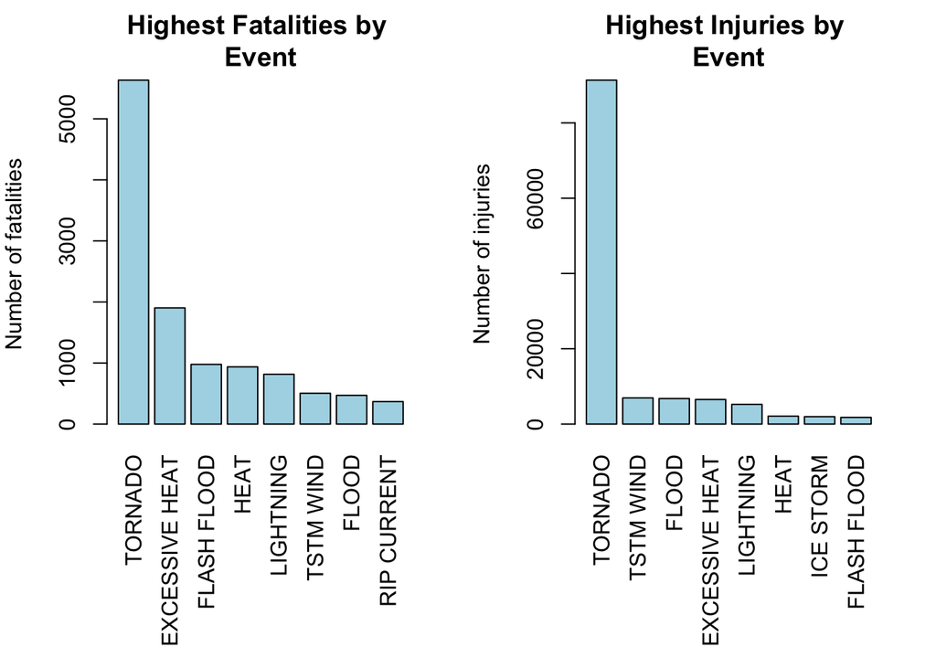

```r
par(mfrow = c(1, 2), mar = c(9, 4, 3, 2))
barplot(fatal_8$FATALITIES, las = 3, names.arg = fatal_8$EVTYPE, main = "Highest Fatalities by \nEvent",
        ylab = "Number of fatalities", col = "light blue")
barplot(injury_8$INJURIES, las = 3, names.arg = injury_8$EVTYPE, main = "Highest Injuries by \nEvent",
        ylab = "Number of injuries", col = "light blue")
```

The plots above indicate that the natural events that have the largest impact on people in terms of fatalities, are tornados: 91346 injuries and 5633 deaths over the period investigated.

Now let’s look at which natural events cause the most damage to property and crops.

### What are the effects of these natural events on property and crops?

```r
prop_8<-propdmg[order(-propdmg$PROPDMGVAL), ][1:8, ]
crop_8<-cropdmg[order(-cropdmg$CROPDMGVAL), ][1:8, ]
prop_8
```

```
##                EVTYPE   PROPDMGVAL
## 170             FLOOD 144657709807
## 411 HURRICANE/TYPHOON  69305840000
## 834           TORNADO  56947380616
## 670       STORM SURGE  43323536000
## 153       FLASH FLOOD  16822673978
## 244              HAIL  15735267513
## 402         HURRICANE  11868319010
## 848    TROPICAL STORM   7703890550
```

```r
crop_8
```

```
##                EVTYPE  CROPDMGVAL
## 95            DROUGHT 13972566000
## 170             FLOOD  5661968450
## 590       RIVER FLOOD  5029459000
## 427         ICE STORM  5022113500
## 244              HAIL  3025954473
## 402         HURRICANE  2741910000
## 411 HURRICANE/TYPHOON  2607872800
## 153       FLASH FLOOD  1421317100
```

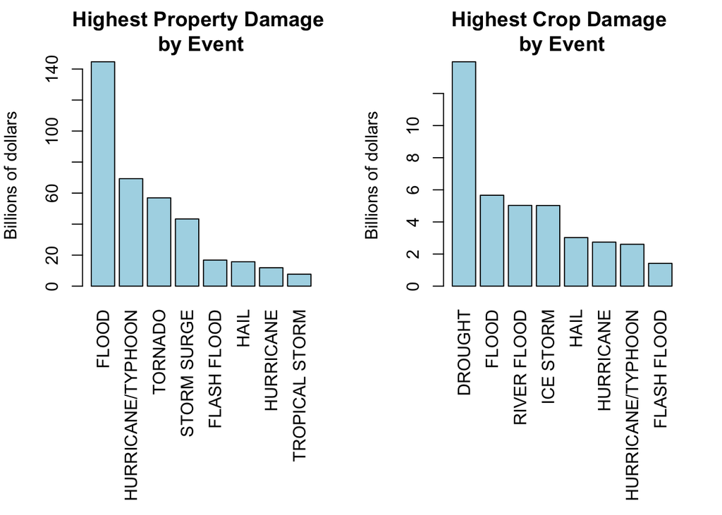

```r
par(mfrow = c(1, 2), mar = c(11, 4, 3, 2))
barplot(prop_8$PROPDMGVAL/(10^9), las = 3, names.arg = prop_8$EVTYPE, main = "Highest Property Damage \nby Event",
        ylab = "Billions of dollars", col = "light blue")
barplot(crop_8$CROPDMGVAL/(10^9), las = 3, names.arg = crop_8$EVTYPE, main = "Highest Crop Damage \nby Event",
        ylab = "Billions of dollars", col = "light blue")
```

## Summary

In this project, we analyze the Storm Events Database created by the US NOAA (The National Oceanographic and Atmospheric Administration). The file documents

The occurrence of storms and other significant weather phenomena having sufficient intensity to cause loss of life, injuries, significant property damage, and/or disruption to commerce;

Rare, unusual, weather phenomena that generate media attention, such as snow flurries in South Florida or the San Diego coastal area; and

Other significant meteorological events, such as record maximum or minimum temperatures or precipitation that occur in connection with another event.

The data cover the years 1950 to 2011.

Using this datase, we were asked to answer the two questions: 1. Across the United States, which types of events are most harmful with respect to population health? 2. Across the United States, which types of events have the greatest economic consequences?

The first set of histograms show that of all the effect of natural events between 1950 and 2011 causing harm to people, tornados topped the list causing 5633 deaths and 91346 injuries. After tornados, excessive heat causes the second most deaths with 1903; wind from thunderstorms causes the 2nd most injuries, with 6957.

The second set of histrograms indicate that changes in the water cycle cause the largest damage to property and crops. Flooding causes the most damage to property (144 billion dollars) and drought causes the most damage to crops (13 billion dollars).